# Final Project Presentation

Lauren Walko

December 9, 2020

# Guiding Question

Does mask wearing have an effect on the amount of positive COVID-19 cases in a State?

## Project Background

The goal of my project is to determine if mask wearing has an effect on the number of positive COVID-19 cases in a state. I found three data sets to use. I have found the states with the highest number of cases, and I am going to use that to compare to the mask wearing frequency in those states.

## Load packages

```r
library(DataComputing)
library(tidyverse)
library(mosaic)
library(lubridate)
```

## Load the Data

This data set was a survery done by the New York Times regarding mask wearing in an area.

```r
masks <- read.csv("/home/ltw5073/Final Project/masks.csv")
head(masks)
```

|  | COUNTYFP | NEVER | RARELY | SOMETIMES | FREQUENTLY | ALWAYS |
| --- | --- | --- | --- | --- | --- | --- |
| 1 | 1001 | 0.053 | 0.074 | 0.134 | 0.295 | 0.444 |
| 2 | 1003 | 0.083 | 0.059 | 0.098 | 0.323 | 0.436 |
| 3 | 1005 | 0.067 | 0.121 | 0.120 | 0.201 | 0.491 |
| 4 | 1007 | 0.020 | 0.034 | 0.096 | 0.278 | 0.572 |
| 5 | 1009 | 0.053 | 0.114 | 0.180 | 0.194 | 0.459 |
| 6 | 1011 | 0.031 | 0.040 | 0.144 | 0.286 | 0.500 |

```r
cases <- read.csv("/home/ltw5073/Final Project/cases.csv")
head(cases)
```

|  | date | state | cases | daily.increase |
| --- | --- | --- | --- | --- |
| 1 | 1/21/20 | Washington | 1 | 1 |
| 2 | 1/22/20 | Washington | 1 | 0 |
| 3 | 1/23/20 | Washington | 1 | 0 |
| 4 | 1/24/20 | Illinois | 1 | 1 |
| 5 | 1/24/20 | Washington | 1 | 0 |
| 6 | 1/25/20 | California | 1 | 1 |

```r
data("ZipGeography")
head(ZipGeography)
```

|  | State | Population | HousingUnits | LandArea | WaterArea | CityName | PostOfficeName | County | AreaCode | Timezone | Latitude | Longitude | ZIP |
| --- | --- | --- | --- | --- | --- | --- | --- | --- | --- | --- | --- | --- | --- |
| 1 | New York | 0 | 0 | 0.1 | 46.3 | Holtsville | Holtsville | Suffolk | 631 | EST | 40.92233 | -72.63708 | 00501 |
| 2 | New York | 0 | 0 | 0.0 | 170.3 | Holtsville | Holtsville | Suffolk | 631 | EST | 40.92233 | -72.63708 | 00544 |
| 3 |  | 0 | 0 | 0.0 | 4.7 | Adjuntas | Adjuntas | Adjuntas | 787 | EST+1 | 18.16527 | -66.72258 | 00601 |
| 4 |  | 42042 | 15590 | 80.1 | 0.0 | Aguada | Aguada | Aguada | 787 | EST+1 | 18.39310 | -67.18095 | 00602 |
| 5 |  | 55530 | 21626 | 78.7 | 0.1 | Aguadilla | Aguadilla | Aguadilla | 787 | EST+1 | 18.45591 | -67.14578 | 00603 |
| 6 |  | 0 | 0 | 0.0 | 20.8 | Aguadilla | Aguadilla | Aguadilla | 787 | EST+1 | 18.49352 | -67.13588 | 00604 |

```r
caseperstate <-
  cases %>%
  group_by(state) %>%
  summarise(total = sum(daily.increase))
```

```r
caseperstate %>%
  arrange(desc(total))
```

| state | total |
| --- | --- |
| California | 1371940 |
| Texas | 1344195 |
| Florida | 1058066 |
| Illinois | 788922 |
| New York | 710612 |
| Georgia | 483106 |
| Ohio | 475024 |
| Wisconsin | 441067 |
| Michigan | 426124 |
| Pennsylvania | 423828 |

[output cut: 46 more lines]

## Bar plot of states with more than 400,000 cases

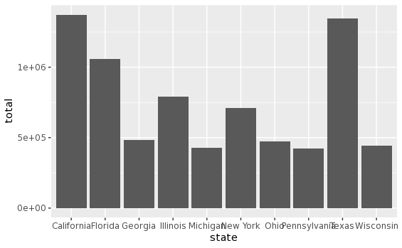

```r
caseperstate %>%
  filter(total > 400000) %>%
  ggplot(aes(x=state, y=total)) +
  geom_bar(stat = 'identity',position='dodge',width=.9)
```

## Final Thoughts

My motivation for this project is to show whether the use of masks has helped a state have less positive cases. It has been an issue that some states wear masks, while others do not, so I want to determine if the states that have consisently worn them have less cases.